# Worked example: Type 3 data - pressure thresholds

- Show All Code
- Hide All Code
- View Source

Author

Stephen Duncombe-Smith (stephen.duncombe-smith@jncc.gov.uk)

Modified

March 13, 2026

## Introduction

Script to make a worked example of using the pressure thresholds from type 3 data in combination with BH3a

## Setup

```r
# Define packages:
packages = c("readxl",
             "ggplot2",
             "dplyr",
             "tidyr",
             "sf",
             "readr",
             "DT",
             "csquares",
             "RColorBrewer",
             "scales",
             "rnaturalearth",
             "details",
             "report")
```

```r
# Install any packages not installed (only run if some are not installed):
installed_packages <- packages %in% rownames(installed.packages())
if (any(installed_packages == FALSE)) {
  install.packages(packages[!installed_packages])
}
```

```r
# Load packages:
invisible(lapply(packages, library, character.only = TRUE))
```

## Data preparation

load the type 3 threshold data and format/filter for use

```r
# set folder for data
data_folder <- "C:/Users/Stephen.Duncombe-Smi/Documents/_Project Shortcuts/ICES/WKBENTH4/SharePoint_COPY_1_01-03-2026/06. Data/"

# load the type 3 thresholds data from the clustering analysis
type3_thresholds <- read_excel(paste0(data_folder, "Data_type_3_threholds_pressure_state.xlsx"), sheet = 1)

# load metadata (taken from type 3 cluster formatting scripts)
gear_meta <- readRDS(paste0(data_folder, "Type3/gear_counts.rds"))
pressure_meta <- readRDS(paste0(data_folder, "Type3/pressure_counts.rds"))

###

# load spatial data from FBIT for c-squares
# these are needed because they have habitat assigned by c-square
load("C:/Users/Stephen.Duncombe-Smi/Documents/GitHub/FBIT/1 - Input env/Bay of Biscay and the Iberian Coast_MSFD_per_csquare.RData")
# convert to csquare class
msfd_csq <- as_csquares(msfd_csq, csquares = "csquares")
# create spatial object
msfd_csq_sf <- st_as_sf(msfd_csq)

###


vms <- st_read("J:/GISprojects/Marine/MSFD/Physical_Damage_Indicator/NEA_PANACEA/Pressure_VMS/Data/Raw/20210924_ICES_Abrasion_Layers/total-2018.shp",
               quiet = TRUE)
```

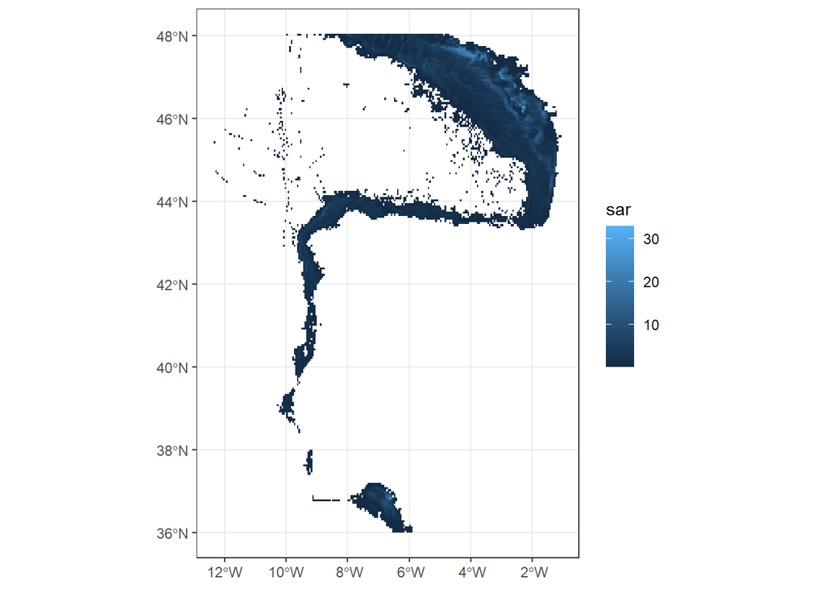

```r
# load some example fishing pressure data to use as an example for 5 yeat average SAR
vms_folder <- "J:/GISprojects/Marine/MSFD/Physical_Damage_Indicator/NEA_PANACEA/Pressure_VMS/Data/Raw/20210924_ICES_Abrasion_Layers/"
# load annual layers
vms_16 = as.data.frame(st_read(paste0(vms_folder, "total-2016.shp"), quiet = TRUE))
vms_17 = as.data.frame(st_read(paste0(vms_folder, "total-2017.shp"), quiet = TRUE))
vms_18 = as.data.frame(st_read(paste0(vms_folder, "total-2018.shp"), quiet = TRUE))
vms_19 = as.data.frame(st_read(paste0(vms_folder, "total-2019.shp"), quiet = TRUE))
vms_20 = as.data.frame(st_read(paste0(vms_folder, "total-2020.shp"), quiet = TRUE))

# function to prep sar data
sar_prep = function(x){
  x %>%
    select(c("C.square", "sar")) %>%
    mutate(sar = if_else(is.na(sar), 0, sar))  # fill NAs with 0 (no pressure)
}

# prep data
vms_16 <- sar_prep(vms_16)
vms_17 <- sar_prep(vms_17)
vms_18 <- sar_prep(vms_18)
vms_19 <- sar_prep(vms_19)
vms_20 <- sar_prep(vms_20)

# create 5 year SAR average (this is just for the example)
vms_5yr <- rbind(vms_16, vms_17, vms_18, vms_19, vms_20) %>%
  group_by(C.square) %>%
  summarise(sar = mean(sar, na.rm = TRUE), .groups = "drop")

# join example SAR values to MSFD grid
msfd_csq_sf_vms <- left_join(msfd_csq_sf, vms_5yr, by = c("csquares" = "C.square"))

# remove NA SAR areas
msfd_csq_sf_vms <- msfd_csq_sf_vms |>
  filter(!is.na(sar))

# plot to sense check
msfd_csq_sf_vms |>
  ggplot() +
  geom_sf(aes(fill = sar), colour = NA) +
  theme_bw()
```

```r
# tidy up
rm(vms_16, vms_17, vms_18, vms_19, vms_20, vms_5yr)
```

```r
# combine hammon and day grab gear types
# (assuming they have been combined in the thresholds analysis)
gear_meta <- gear_meta |>
  rename(DATASET = dataset) |>
  select(-n) |>
  mutate(gear = if_else(grepl("hamon|day", gear), "day-hammon_grab", gear)) |>
  group_by(.drop = TRUE) |>
  distinct_all()

pressure_meta <- pressure_meta |>
  rename(DATASET = dataset) |>
  select(-n) |>
  group_by(.drop = TRUE)

# join gear and pressure type metadata
type3_thresholds <- left_join(type3_thresholds ,gear_meta, by = "DATASET")
type3_thresholds <- left_join(type3_thresholds ,pressure_meta, by = "DATASET")

# Classify infaunal datasets
infauna_datasets <- c("NS_BEhabitats", "NS_NLhabitats", "NS_DKhabitats", "CS_NS_UKhabitats")

# Regions (dataset lists provided)
wms_datasets <- c("WMS_IEOESPhabitats", "WMS_EShabitats", "WMS_FRMEDITS","WMS_ISCMS_IRBIMCNR", "WMS_NOURMED", "WMS_APPEALMED")
bobic_cs_datasets <- c("BoBIC_IberianChabitats", "BoBIC_GulfofCadizhabitats", "BoBIC_CGFS","FR_ORHAGO", "CS_EVHOE")
gns_datasets <- c("CS_NS_IBTSFR","NS_BEhabitats", "NS_NLhabitats", "NS_DKhabitats", "CS_NS_UKhabitats")

# fix error in value ("0.98.")
type3_thresholds <- type3_thresholds |>
  mutate(NV_S.TH = if_else(DATASET == "WMS_ISCMS_IRBIMCNR" & INDICATOR == "Biomass", "0.98", NV_S.TH))

# format thresholds
type3_thresholds_format <- type3_thresholds %>%
  gather(THRESHOLD_METHOD, value, -DATASET, -INDICATOR, -BHT, -N, -PVALUE, -gear, -pressure_type) %>%
  mutate(REGION = case_when(
    DATASET %in% wms_datasets      ~ "Western Mediterranean Sea",
    DATASET %in% bobic_cs_datasets ~ "Bay of Biscay & Iberian Coast + Celtic Seas",
    DATASET %in% gns_datasets      ~ "Greater North Sea",
    TRUE                           ~ NA_character_
  ),
  FAUNA = if_else(DATASET %in% infauna_datasets, "Infauna", "Epifauna")
  ) %>%
  filter(!is.na(value)) %>%
  mutate(value = as.numeric(value)) %>%
  mutate_if(is.character,as.factor)


### simplify
df_wide_p <- type3_thresholds_format |>
  filter(THRESHOLD_METHOD %in% c("NV_P.TH", "DC_P.TH")) |>
  select(DATASET, REGION, INDICATOR, BHT, FAUNA, THRESHOLD_METHOD, value, pressure_type, gear) |>
  pivot_wider(names_from = THRESHOLD_METHOD, values_from = value) |>
  filter(!is.na(`NV_P.TH`), !is.na(`DC_P.TH`))
```

```r
# check pressure types, gears, indicators
df_wide_p |>
  group_by(INDICATOR, pressure_type, gear) |>
  tally(sort = TRUE)
```

```
# A tibble: 21 × 4
# Groups:   INDICATOR, pressure_type [13]
   INDICATOR        pressure_type    gear                n
   <fct>            <fct>            <fct>           <int>
 1 Biomass          SAR_5yr_avg      otter_trawl        16
 2 SoS              SAR_5yr_avg      otter_trawl        16
 3 Richness         SAR_5yr_avg      otter_trawl         9
 4 Log1p (abundan.) subSAR_total_avg day-hammon_grab     3
 5 Margalef         SAR_5yr_avg      otter_trawl         3
 6 Richness         subSAR_total_avg day-hammon_grab     3
 7 Biomass          SAR_3yr_avg      otter_trawl         2
 8 Margalef         SAR_5yr_avg      box_corer           2
 9 SoS              SAR_5yr_avg      beam_trawl          2
10 SoS              SAR_5yr_avg      bottom_trawl        2
# ℹ 11 more rows
```

```r
# very few values for most
# take just otter trawls and SAR 5 yr average

df_wide_p <- df_wide_p |>
  filter(pressure_type == "SAR_5yr_avg") |>
  filter(gear == "otter_trawl")
```

## Plot data

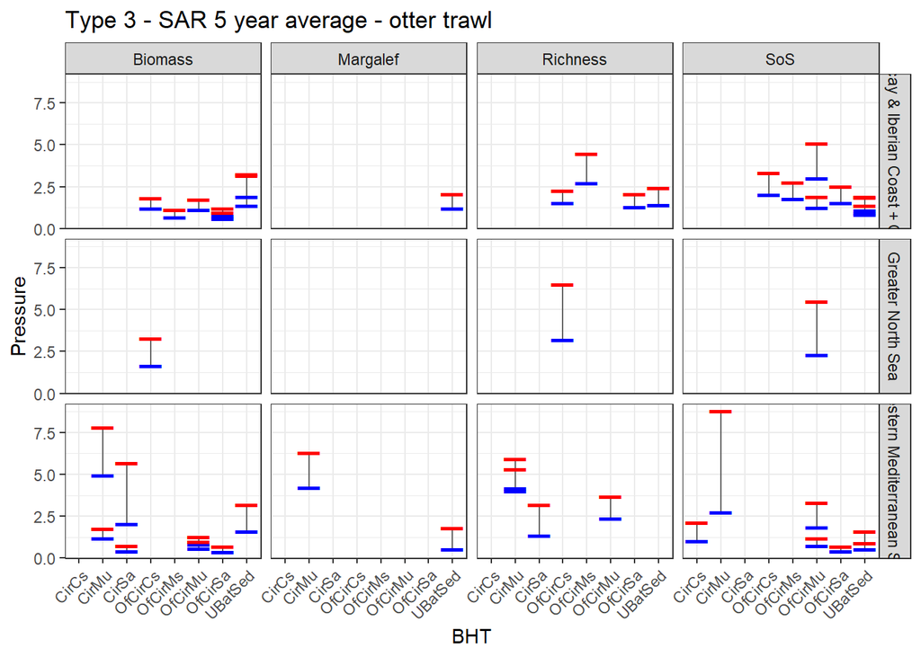

```r
# plot ranges between NV and DC pressure thresholds
df_wide_p |>
  ggplot(aes(x = BHT)) +
  geom_linerange(aes(ymin = NV_P.TH, ymax = DC_P.TH), colour = "grey40") +
  geom_point(aes(y = NV_P.TH), shape = 95, size = 7, colour = "blue") +
  geom_point(aes(y = DC_P.TH), shape = 95, size = 7, colour = "red") +
  theme_bw() +
  labs(title = "Type 3 - SAR 5 year average - otter trawl", x = "BHT", y = "Pressure") +
  theme(axis.text.x = element_text(angle = 45, hjust = 1)) +
  facet_grid(rows = vars(REGION), cols = vars(INDICATOR))
```

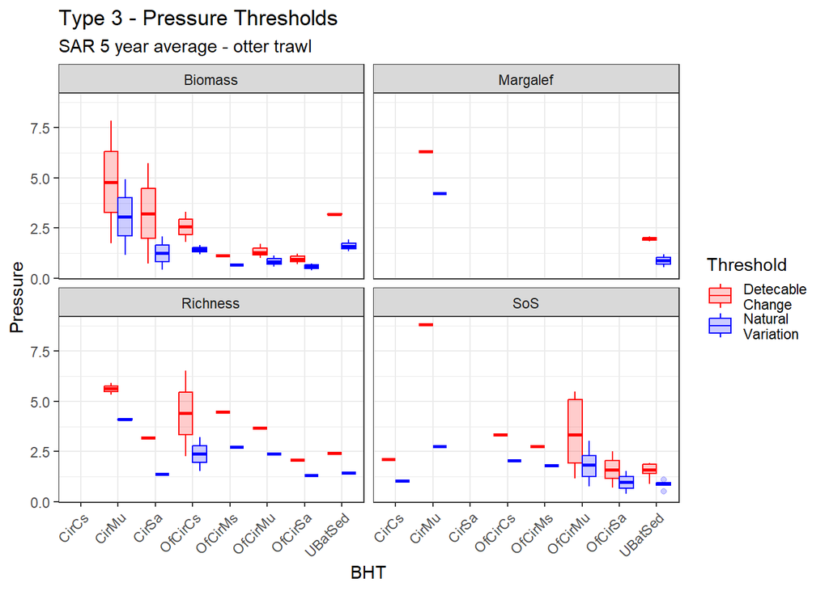

```r
# group regions and add legend to plot
p <- df_wide_p |>
  pivot_longer(
    cols = c(NV_P.TH, DC_P.TH),
    names_to = "threshold",
    values_to = "pressure"
  ) |>
  mutate(
    threshold = recode(threshold,
                       NV_P.TH = "Natural \nVariation",
                       DC_P.TH = "Detecable \nChange")
  ) |>
  ggplot(aes(x = BHT, y = pressure, fill = threshold, colour = threshold)) +
  geom_boxplot(alpha = 0.2, position = position_dodge(width = 0.75)) +
  theme_bw() +
  labs(
    title = "Type 3 - Pressure Thresholds", subtitle = "SAR 5 year average - otter trawl",
    x = "BHT", y = "Pressure",
    fill = "Threshold", colour = "Threshold"  # legend titles (edit as you like)
  ) +
  scale_fill_manual(values = c("Natural \nVariation" = "blue", "Detecable \nChange" = "red")) +
  scale_colour_manual(values = c("Natural \nVariation" = "blue", "Detecable \nChange" = "red")) +
  theme(axis.text.x = element_text(angle = 45, hjust = 1)) +
  facet_wrap(~INDICATOR)

p
```

```r
#ggsave(file = "type3_pth.png", width = 25, height = 20, units = "cm", p)
```

Limit to one region for worked example

```r
# limit to Bay of Biscay & Iberian Coast + Celtic Seas
# these regions have the most data across habitats
df_wide_p <- df_wide_p |>
  filter(REGION == "Bay of Biscay & Iberian Coast + Celtic Seas")
```

## Worked example (BH3-like approach)

These pressure thresholds can be used to calibrate the BH3 matrix to create a risk-based assessment of pressures on habitats.

BH3 uses a matrix approach to estimate risk of disturbance (condition degredation) to habitats based on their sensitivity to the pressure and the magnitude of the pressure.

The pressure thresholds derived from the type 3 data (or other data) can be used to represent what range of pressures that represent a risk to the habitat conditon. The lowest pressure threshold can define the level of pressure that below wich there is no detacbale risk of disturbance. The highest threshold can define the level of pressure above which there is a very high risk of disturbance.

The threshold values can also be adapted dependent on the confidence needed, for example, increased up to a point in which there is a 90% confidence they represent a change in condition.

```r
# find min and max pressure thresholds for each BHT
bht_pressures <- df_wide_p %>%
  mutate(
    row_min_value = pmin(NV_P.TH, DC_P.TH, na.rm = TRUE),
    row_min_source = case_when(
      is.na(NV_P.TH) & is.na(DC_P.TH) ~ NA_character_,
      is.na(DC_P.TH) ~ "NV_P.TH",
      is.na(NV_P.TH) ~ "DC_P.TH",
      NV_P.TH <= DC_P.TH ~ "NV_P.TH",
      TRUE ~ "DC_P.TH"
    ),
    row_max_value = pmax(NV_P.TH, DC_P.TH, na.rm = TRUE),
    row_max_source = case_when(
      is.na(NV_P.TH) & is.na(DC_P.TH) ~ NA_character_,
      is.na(DC_P.TH) ~ "NV_P.TH",
      is.na(NV_P.TH) ~ "DC_P.TH",
      NV_P.TH >= DC_P.TH ~ "NV_P.TH",
      TRUE ~ "DC_P.TH"
    )
  ) %>%
  group_by(BHT) %>%
  summarise(
    # pick the best (single) row per BHT for min and max
    min_value  = min(row_min_value, na.rm = TRUE),
    min_source = row_min_source[which.min(row_min_value)],
    max_value  = max(row_max_value, na.rm = TRUE),
    max_source = row_max_source[which.max(row_max_value)],
    .groups = "drop"
  )

# show in table
datatable(bht_pressures)
```

|  | BHT | min_value | min_source | max_value | max_source |
| --- | --- | --- | --- | --- | --- |
| 1 | OfCirCs | 1.21 | NV_P.TH | 3.35 | DC_P.TH |
| 2 | OfCirMs | 0.68 | NV_P.TH | 4.47 | DC_P.TH |
| 3 | OfCirMu | 1.13 | NV_P.TH | 5.09 | DC_P.TH |
| 4 | OfCirSa | 0.59 | NV_P.TH | 2.51 | DC_P.TH |
| 5 | UBatSed | 0.84 | NV_P.TH | 3.24 | DC_P.TH |

```r
# count how many intermediate pressure thresholds there are between min and max
intermediate_p_counts <- df_wide_p %>%
  mutate(
    row_min = pmin(NV_P.TH, DC_P.TH, na.rm = TRUE),
    row_max = pmax(NV_P.TH, DC_P.TH, na.rm = TRUE)
  ) %>%
  group_by(BHT) %>%
  summarise(
    min_value = min(row_min, na.rm = TRUE),
    max_value = max(row_max, na.rm = TRUE),

    n_intermediate = sum(
      (NV_P.TH > min_value & NV_P.TH < max_value) +
        (DC_P.TH > min_value & DC_P.TH < max_value),
      na.rm = TRUE
    ),
    .groups = "drop"
  )

# show in table
datatable(intermediate_p_counts)
```

|  | BHT | min_value | max_value | n_intermediate |
| --- | --- | --- | --- | --- |
| 1 | OfCirCs | 1.21 | 3.35 | 4 |
| 2 | OfCirMs | 0.68 | 4.47 | 4 |
| 3 | OfCirMu | 1.13 | 5.09 | 4 |
| 4 | OfCirSa | 0.59 | 2.51 | 6 |
| 5 | UBatSed | 0.84 | 3.24 | 12 |

```r
# look at segmenting intermediate threshold values between the min and max
# note, these still include both NV and DC thresholds, but it could be made to work on just one type of threshold.
# also, could be limitted to single indicator, or a subset. below is just an example to try the method

n_target <- 6

df_standardised_between <- df_wide_p %>%
  mutate(
    row_min = pmin(NV_P.TH, DC_P.TH, na.rm = TRUE),
    row_max = pmax(NV_P.TH, DC_P.TH, na.rm = TRUE)
  ) %>%
  group_by(BHT) %>%
  mutate(
    min_value = min(row_min, na.rm = TRUE),
    max_value = max(row_max, na.rm = TRUE)
  ) %>%
  ungroup() %>%
  pivot_longer(
    cols = c(NV_P.TH, DC_P.TH),
    names_to = "source",
    values_to = "value"
  ) %>%
  filter(!is.na(value), value > min_value, value < max_value) %>%
  arrange(BHT, value) %>%
  group_by(BHT) %>%
  group_modify(\(.x, .y) {
    minv <- unique(.x$min_value)
    maxv <- unique(.x$max_value)

    cand <- .x %>% distinct(value, .keep_all = TRUE) %>% arrange(value)

    out <- if (nrow(cand) >= n_target) {
      idx <- unique(round(seq(1, nrow(cand), length.out = n_target)))
      cand[idx, , drop = FALSE] %>%
        mutate(chosen_from = "observed_intermediate")
    } else {
      need <- n_target - nrow(cand)
      filler_vals <- seq(minv, maxv, length.out = need + 2)[-c(1, need + 2)]
      filler <- tibble(
        min_value = minv,
        max_value = maxv,
        source = NA_character_,
        value = filler_vals,
        chosen_from = "range_fill"
      )
      bind_rows(
        cand %>% mutate(chosen_from = "observed_intermediate"),
        filler
      ) %>% arrange(value)
    }

    out %>% mutate(order = row_number())
  }) %>%
  ungroup() %>%
  select(BHT, min_value, max_value, order, value, source, chosen_from)

datatable(df_standardised_between)
```

|  | BHT | min_value | max_value | order | value | source | chosen_from |
| --- | --- | --- | --- | --- | --- | --- | --- |
| 1 | OfCirCs | 1.21 | 3.35 | 1 | 1.54 | NV_P.TH | observed_intermediate |
| 2 | OfCirCs | 1.21 | 3.35 | 2 | 1.82 | DC_P.TH | observed_intermediate |
| 3 | OfCirCs | 1.21 | 3.35 | 3 | 1.923333333333333 |  | range_fill |
| 4 | OfCirCs | 1.21 | 3.35 | 4 | 2.04 | NV_P.TH | observed_intermediate |
| 5 | OfCirCs | 1.21 | 3.35 | 5 | 2.26 | DC_P.TH | observed_intermediate |
| 6 | OfCirCs | 1.21 | 3.35 | 6 | 2.636666666666667 |  | range_fill |
| 7 | OfCirMs | 0.68 | 4.47 | 1 | 1.13 | DC_P.TH | observed_intermediate |
| 8 | OfCirMs | 0.68 | 4.47 | 2 | 1.8 | NV_P.TH | observed_intermediate |
| 9 | OfCirMs | 0.68 | 4.47 | 3 | 1.943333333333333 |  | range_fill |
| 10 | OfCirMs | 0.68 | 4.47 | 4 | 2.73 | NV_P.TH | observed_intermediate |

[output cut: 20 more lines]

```r
# try the above approach to give 8 pressure values that capture the range of pressure thresholds
# these could be seen as decreasing certanity of the pressure having a detremental impact on the condition (risk of disturbance)
# also screened by region/MRU

n_target <- 6  # number of values INCLUDING min and max (so first=min, last=max)

# 1) Global min/max per BHT (across both NV_P.TH and DC_P.TH) + which column they came from
bht_minmax <- df_wide_p %>%
  mutate(
    row_min = pmin(NV_P.TH, DC_P.TH, na.rm = TRUE),
    row_max = pmax(NV_P.TH, DC_P.TH, na.rm = TRUE),
    row_min_source = case_when(
      is.na(NV_P.TH) & is.na(DC_P.TH) ~ NA_character_,
      is.na(DC_P.TH) ~ "NV_P.TH",
      is.na(NV_P.TH) ~ "DC_P.TH",
      NV_P.TH <= DC_P.TH ~ "NV_P.TH",
      TRUE ~ "DC_P.TH"
    ),
    row_max_source = case_when(
      is.na(NV_P.TH) & is.na(DC_P.TH) ~ NA_character_,
      is.na(DC_P.TH) ~ "NV_P.TH",
      is.na(NV_P.TH) ~ "DC_P.TH",
      NV_P.TH >= DC_P.TH ~ "NV_P.TH",
      TRUE ~ "DC_P.TH"
    )
  ) %>%
  group_by(BHT) %>%
  summarise(
    min_value = min(row_min, na.rm = TRUE),
    max_value = max(row_max, na.rm = TRUE),
    min_source = row_min_source[which.min(row_min)],
    max_source = row_max_source[which.max(row_max)],
    .groups = "drop"
  )

# 2) Candidate observed values (both columns), tagged and filtered to [min, max]
obs_long <- df_wide_p %>%
  select(BHT, NV_P.TH, DC_P.TH) %>%
  pivot_longer(
    cols = c(NV_P.TH, DC_P.TH),
    names_to = "source",
    values_to = "value"
  ) %>%
  filter(!is.na(value)) %>%
  inner_join(bht_minmax, by = "BHT") %>%
  filter(value >= min_value, value <= max_value)

# 3) For each BHT, create exactly n_target ordered values from min->max:
#    - always include min and max (with their sources from bht_minmax)
#    - try to use observed values between them
#    - if not enough, fill with equally spaced values in the range
df_standardised_long <- bht_minmax %>%
  group_by(BHT) %>%
  group_modify(\(.x, .y) {
    bht <- .y$BHT
    minv <- .x$min_value[[1]]
    maxv <- .x$max_value[[1]]
    minsrc <- .x$min_source[[1]]
    maxsrc <- .x$max_source[[1]]

    # if min==max, the whole "range" collapses: repeat the single value
    if (isTRUE(all.equal(minv, maxv))) {
      out <- tibble(
        value = rep(minv, n_target),
        chosen_from = "range_fill",
        source = NA_character_
      )
      # keep the endpoint source on first/last row (they're the same value)
      if (n_target >= 1) out$source[1] <- minsrc
      if (n_target >= 2) out$source[n_target] <- maxsrc

      return(out %>% mutate(order = row_number(), point_type = "range"))
    }

    # observed candidates for this BHT
    cand <- obs_long %>%
      filter(BHT == bht) %>%
      distinct(value, .keep_all = TRUE) %>%  # drop if you want duplicates
      arrange(value)

    # interior observed values strictly between endpoints
    interior_obs <- cand %>%
      filter(value > minv, value < maxv) %>%
      transmute(value, chosen_from = "observed", source)

    n_interior_needed <- max(n_target - 2, 0)

    min_endpoint <- tibble(value = minv, chosen_from = "endpoint", source = minsrc)
    max_endpoint <- tibble(value = maxv, chosen_from = "endpoint", source = maxsrc)

    if (n_interior_needed == 0) {
      out <- bind_rows(min_endpoint, max_endpoint)
    } else if (nrow(interior_obs) >= n_interior_needed) {
      idx <- unique(round(seq(1, nrow(interior_obs), length.out = n_interior_needed)))
      out <- bind_rows(
        min_endpoint,
        interior_obs[idx, , drop = FALSE],
        max_endpoint
      )
    } else {
      need <- n_interior_needed - nrow(interior_obs)
      filler_vals <- seq(minv, maxv, length.out = need + 2)[-c(1, need + 2)]

      filler <- tibble(
        value = filler_vals,
        chosen_from = "range_fill",
        source = NA_character_
      )

      out <- bind_rows(
        min_endpoint,
        interior_obs,
        filler,
        max_endpoint
      ) %>% arrange(value)
    }

    out %>%
      mutate(
        order = row_number(),
        point_type = case_when(
          order == 1 ~ "min",
          order == n() ~ "max",
          TRUE ~ "intermediate"
        )
      )
  }) %>%
  ungroup() %>%
  select(BHT, order, point_type, value, chosen_from, source)

# show in a table
datatable(df_standardised_long)
```

|  | BHT | order | point_type | value | chosen_from | source |
| --- | --- | --- | --- | --- | --- | --- |
| 1 | OfCirCs | 1 | min | 1.21 | endpoint | NV_P.TH |
| 2 | OfCirCs | 2 | intermediate | 1.54 | observed | NV_P.TH |
| 3 | OfCirCs | 3 | intermediate | 1.82 | observed | DC_P.TH |
| 4 | OfCirCs | 4 | intermediate | 2.04 | observed | NV_P.TH |
| 5 | OfCirCs | 5 | intermediate | 2.26 | observed | DC_P.TH |
| 6 | OfCirCs | 6 | max | 3.35 | endpoint | DC_P.TH |
| 7 | OfCirMs | 1 | min | 0.68 | endpoint | NV_P.TH |
| 8 | OfCirMs | 2 | intermediate | 1.13 | observed | DC_P.TH |
| 9 | OfCirMs | 3 | intermediate | 1.8 | observed | NV_P.TH |
| 10 | OfCirMs | 4 | intermediate | 2.73 | observed | NV_P.TH |

[output cut: 20 more lines]

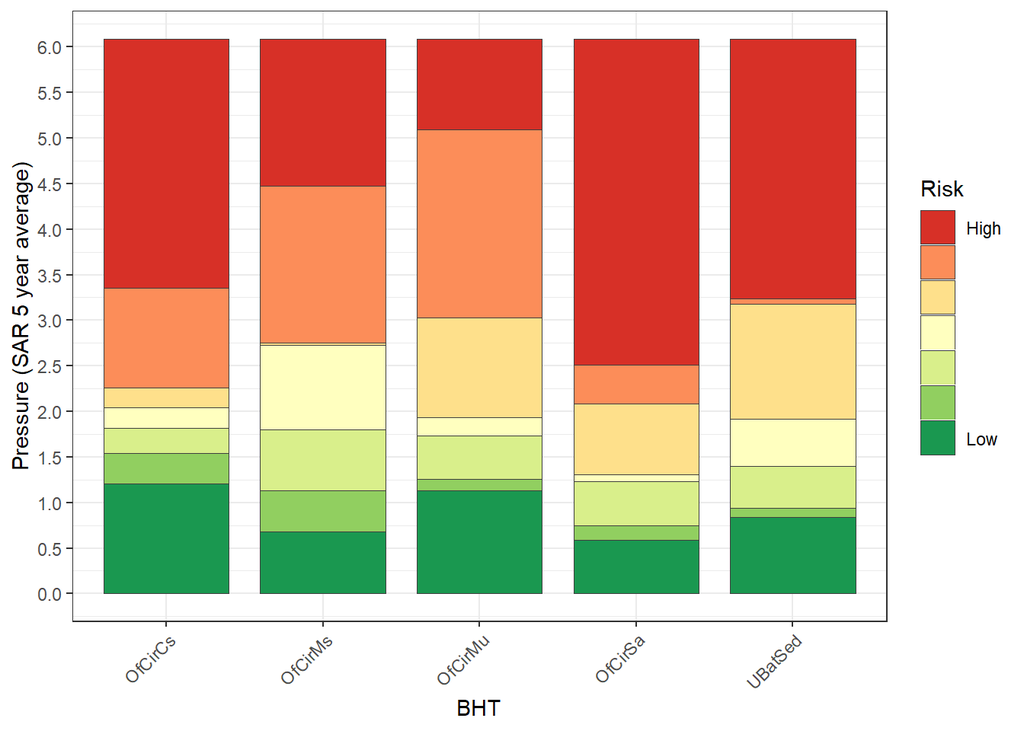

```r
# build plot to show the range of pressure thresholds for each BHT (risk)
bottom_start <- 0
top_buffer <- 1

# 1) Get global top so ALL bars are same height
bht_max <- df_standardised_long %>%
  group_by(BHT) %>%
  summarise(max_value = max(value[point_type == "max"], na.rm = TRUE), .groups = "drop")

global_top <- max(bht_max$max_value, na.rm = TRUE) + top_buffer

# 2) Build segment heights from your ordered points (min + 6 + max = 8 points => 7 segments)
#    Then add bottom segment (0->min) and top segment (max->global_top)
segments_mid <- df_standardised_long %>%
  group_by(BHT) %>%
  arrange(order, .by_group = TRUE) %>%
  mutate(
    value_next = lead(value),
    height = value_next - value
  ) %>%
  filter(!is.na(value_next), height > 0) %>%
  mutate(
    seg_id = row_number(),                    # 1..7 (if 8 points)
    fill_value = (value + value_next) / 2     # midpoint used for gradient mapping
  ) %>%
  ungroup() %>%
  select(BHT, seg_id, height, fill_value)

segment_bottom <- df_standardised_long %>%
  filter(point_type == "min") %>%
  group_by(BHT) %>%
  summarise(
    seg_id = 0L,
    height = pmax(min(value, na.rm = TRUE) - bottom_start, 0),
    fill_value = bottom_start,                # low end of gradient
    .groups = "drop"
  )

segment_top <- df_standardised_long %>%
  filter(point_type == "max") %>%
  group_by(BHT) %>%
  summarise(
    seg_id = 999L,
    height = pmax(global_top - max(value, na.rm = TRUE), 0),
    fill_value = global_top,                  # high end of gradient
    .groups = "drop"
  )

plot_df <- bind_rows(segment_bottom, segments_mid, segment_top) %>%
  group_by(BHT) %>%
  arrange(seg_id, .by_group = TRUE) %>%
  ungroup()

# create palette
risk_palette <- brewer.pal(7, "RdYlGn")

seg_lvls <- c(999, 5, 4, 3, 2, 1, 0)

plot_df <- plot_df |>
  mutate(seg_id = factor(seg_id, levels = seg_lvls))

# 3) Plot with palette so low values are green and high values are red
p2 <- ggplot(plot_df, aes(x = BHT, y = height, fill = seg_id)) +
  geom_col(width = 0.8, colour = "grey25", linewidth = 0.2,
           position = position_stack(reverse = FALSE)) +  # set TRUE if you need to invert
  scale_fill_manual(values = risk_palette,
                    name = "Risk",
                    labels = c("High", "", "", "", "", "", "Low")) +
  labs(x = "BHT", y = "Pressure (SAR 5 year average)") +
  scale_y_continuous(breaks = c(0, 0.5, 1, 1.5, 2, 2.5, 3, 3.5, 4, 4.5, 5, 5.5, 6)) +
  coord_cartesian(ylim = c(bottom_start, global_top)) +
  guides(label = "none") +

  theme_bw() +
  theme(axis.text.x = element_text(angle = 45, hjust = 1))

p2
```

```r
#ggsave(file = "type3_pth_risk.png", width = 20, height = 15, units = "cm", p2)
```

Integrate with BH3 method

```r
# summarise in a matrix style the pressure thresholds

# 1) order BHT levels by highest max (descending)
bht_order <- df_standardised_long %>%
  group_by(BHT) %>%
  summarise(max_value = max(value[point_type == "max"], na.rm = TRUE), .groups = "drop") %>%
  arrange(max_value) %>%
  pull(BHT)

# 2) pivot wider: rows = order (1..8), cols = BHT (sorted by max desc)
df_standardised_wide <- df_standardised_long %>%
  mutate(BHT = factor(BHT, levels = bht_order),
         value = round(value, 2)) %>%
  arrange(BHT, order) %>%
  select(order, BHT, value) %>%
  pivot_wider(
    names_from = BHT,
    values_from = value
  ) %>%
  arrange(order)

datatable(df_standardised_wide, rownames = FALSE)
```

| order | OfCirSa | UBatSed | OfCirCs | OfCirMs | OfCirMu |
| --- | --- | --- | --- | --- | --- |
| 1 | 0.59 | 0.84 | 1.21 | 0.68 | 1.13 |
| 2 | 0.75 | 0.94 | 1.54 | 1.13 | 1.26 |
| 3 | 1.23 | 1.4 | 1.82 | 1.8 | 1.73 |
| 4 | 1.31 | 1.92 | 2.04 | 2.73 | 1.93 |
| 5 | 2.08 | 3.18 | 2.26 | 2.75 | 3.03 |
| 6 | 2.51 | 3.24 | 3.35 | 4.47 | 5.09 |

```r
# apply pressure thresholds and risk levels to spatial data (BH3-like approach)

# add abbreviated BHT codes to MSFD grid
msfd_csq_sf_vms <- msfd_csq_sf_vms |>
  mutate(BHT = case_when(
    MSFD == "Circalittoral coarse sediment" ~ "CirCs",
    MSFD == "Circalittoral mud" ~ "CirMu",
    MSFD == "Circalittoral sand" ~ " CirSa",
    MSFD == "Offshore circalittoral coarse sediment" ~ "OfCirCs",
    MSFD == "Offshore circalittoral mixed sediment" ~ "OfCirMs",
    MSFD == "Offshore circalittoral mud" ~ " OfCirMu",
    MSFD == "Offshore circalittoral sand" ~ "OfCirSa",
    MSFD == "Offshore circalittoral rock and biogenic reef" ~ "OfRoBio",
    MSFD == "Upper bathyal sediment" ~ "UBatSed",
    TRUE ~ NA_character_
  ))

# filter to only habs with pressure thresholds
bhts <- unique(df_standardised_long$BHT)
msfd_csq_sf_vms <- msfd_csq_sf_vms |>
  filter(BHT %in% bhts)


# function to match a SAR value to the pressure threshold intervals for a given BHT
match_interval <- function(bht_code, sar_value, lookup) {
  # Filter for correct BHT
  tbl <- lookup[lookup$BHT == bht_code, ]
  tbl <- tbl[order(tbl$order), ]
  # Extract thresholds
  vals   <- tbl$value
  orders <- tbl$order
  # If below first
  if (sar_value < vals[1]) {
    return(paste0("<", orders[1]))
  }
  # If above last
  if (sar_value > vals[length(vals)]) {
    return(paste0(">", orders[length(orders)]))
  }
  # Otherwise find interval
  idx <- findInterval(sar_value, vals)
  # findInterval gives:
  # 0: below first
  # length(vals): above last
  # otherwise: between vals[idx] and vals[idx+1]
  paste0(orders[idx], "-", orders[idx + 1])
}

# apply function to spatial data
msfd_csq_sf_vms_pt <- msfd_csq_sf_vms |>
  mutate(risk_intervals = mapply(
    match_interval,
    bht_code  = BHT,
    sar_value = sar,
    MoreArgs  = list(lookup = df_standardised_long)
  ))

# create risk colour scale pallette
# define levels
interval_levels <- c("<1", "1-2", "2-3", "3-4", "4-5", "5-6", ">6")
# add as factor
msfd_csq_sf_vms_pt <- msfd_csq_sf_vms_pt |>
  mutate(risk_intervals = factor(risk_intervals,
                                 levels = interval_levels))
```

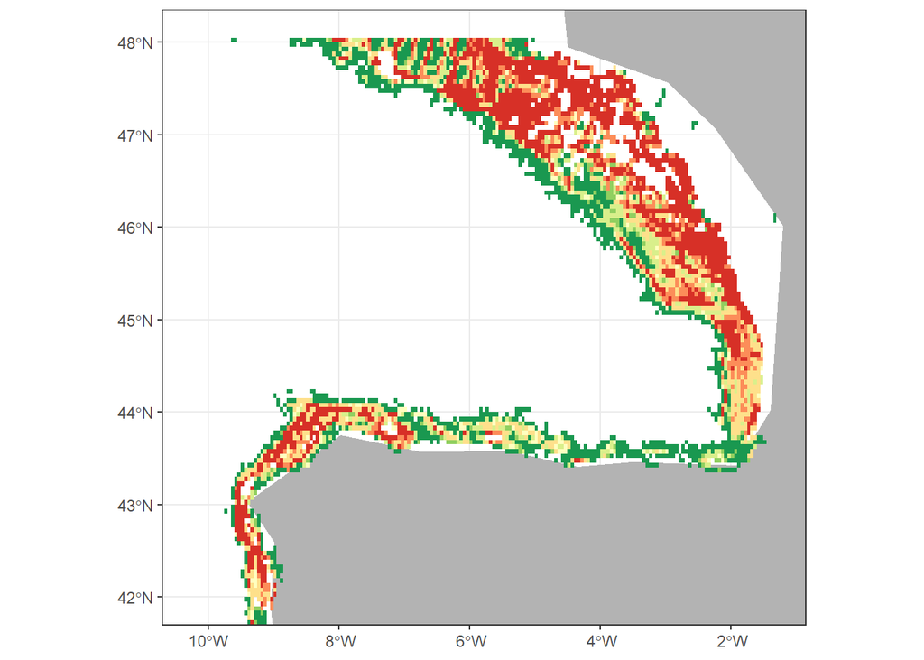

```r
## plot map

# create palette for maps
risk_palette <- rev(brewer.pal(7, "RdYlGn"))

# get land masses for plotting
land <- rnaturalearth::ne_countries(scale = 110,
                                    country = c("france", "spain", "portugal"),
                                    returnclass = "sf")

#bbox <- st_bbox(msfd_csq_sf_vms_pt)

# plot map of risk of disturbance using 5 year average SAR values and pressure thresholds
map <- ggplot() +
  geom_sf(data = land, fill = "grey70", colour = "grey70") +
  geom_sf(data = msfd_csq_sf_vms_pt, aes(fill = risk_intervals), colour = NA) +
  scale_fill_manual(values = risk_palette,
                    name = "Risk") +
  theme_bw() +
  guides(fill = "none") + # help here
  xlim(-10.25, -1.3) +
  ylim(42, 48.05)

map
```

```r
#ggsave(file = "type3_pth_risk_map.png", width = 20, height = 15, units = "cm", map)
```

# References

## Package References

- de Vries P (2024). *csquares: Concise Spatial Query and Representation System (c-Squares)*. doi:10.32614/CRAN.package.csquares https://doi.org/10.32614/CRAN.package.csquares, R package version 0.1.0, https://CRAN.R-project.org/package=csquares.
- Makowski D, Lüdecke D, Patil I, Thériault R, Ben-Shachar M, Wiernik B (2023). “Automated Results Reporting as a Practical Tool to Improve Reproducibility and Methodological Best Practices Adoption.” *CRAN*. https://easystats.github.io/report/.
- Massicotte P, South A (2026). *rnaturalearth: World Map Data from Natural Earth*. doi:10.32614/CRAN.package.rnaturalearth https://doi.org/10.32614/CRAN.package.rnaturalearth, R package version 1.2.0, https://CRAN.R-project.org/package=rnaturalearth.
- Neuwirth E (2022). *RColorBrewer: ColorBrewer Palettes*. doi:10.32614/CRAN.package.RColorBrewer https://doi.org/10.32614/CRAN.package.RColorBrewer, R package version 1.1-3, https://CRAN.R-project.org/package=RColorBrewer.
- Pebesma E, Bivand R (2023). *Spatial Data Science: With applications in R*. Chapman and Hall/CRC. doi:10.1201/9780429459016 https://doi.org/10.1201/9780429459016, https://r-spatial.org/book/. Pebesma E (2018). “Simple Features for R: Standardized Support for Spatial Vector Data.” *The R Journal*, *10*(1), 439-446. doi:10.32614/RJ-2018-009 https://doi.org/10.32614/RJ-2018-009, https://doi.org/10.32614/RJ-2018-009.
- R Core Team (2025). *R: A Language and Environment for Statistical Computing*. R Foundation for Statistical Computing, Vienna, Austria. https://www.R-project.org/.
- Sidi J (2025). *details: Create Details HTML Tag for Markdown and Package Documentation*. doi:10.32614/CRAN.package.details https://doi.org/10.32614/CRAN.package.details, R package version 0.4.0, https://CRAN.R-project.org/package=details.
- Wickham H (2016). *ggplot2: Elegant Graphics for Data Analysis*. Springer-Verlag New York. ISBN 978-3-319-24277-4, https://ggplot2.tidyverse.org.
- Wickham H, Bryan J (2025). *readxl: Read Excel Files*. doi:10.32614/CRAN.package.readxl https://doi.org/10.32614/CRAN.package.readxl, R package version 1.4.5, https://CRAN.R-project.org/package=readxl.
- Wickham H, François R, Henry L, Müller K, Vaughan D (2023). *dplyr: A Grammar of Data Manipulation*. doi:10.32614/CRAN.package.dplyr https://doi.org/10.32614/CRAN.package.dplyr, R package version 1.1.4, https://CRAN.R-project.org/package=dplyr.
- Wickham H, Hester J, Bryan J (2024). *readr: Read Rectangular Text Data*. doi:10.32614/CRAN.package.readr https://doi.org/10.32614/CRAN.package.readr, R package version 2.1.5, https://CRAN.R-project.org/package=readr.
- Wickham H, Pedersen T, Seidel D (2025). *scales: Scale Functions for Visualization*. doi:10.32614/CRAN.package.scales https://doi.org/10.32614/CRAN.package.scales, R package version 1.4.0, https://CRAN.R-project.org/package=scales.
- Wickham H, Vaughan D, Girlich M (2024). *tidyr: Tidy Messy Data*. doi:10.32614/CRAN.package.tidyr https://doi.org/10.32614/CRAN.package.tidyr, R package version 1.3.1, https://CRAN.R-project.org/package=tidyr.
- Xie Y, Cheng J, Tan X (2024). *DT: A Wrapper of the JavaScript Library ‘DataTables’*. doi:10.32614/CRAN.package.DT https://doi.org/10.32614/CRAN.package.DT, R package version 0.33, https://CRAN.R-project.org/package=DT.

## Session Info

```r
details::details(sessionInfo(), summary = 'sessionInfo')
```

**sessionInfo**